# Import and explore covariates

Aidan Brushett

2025-03-29

# 0. Before you begin

Aidan Brushett M.Sc. Student University of Victoria  
School of Environmental Studies  
Email: aidanbrushett@uvic.ca

# 1. Setup

```r
rm(list=ls()) # start fresh :)

library(tidyverse)
```

```r
library(ggplot2)
library(writexl)
# These are functions that can sometimes get masked by other packages. Shouldn't be an issue and could be removed.
select <- dplyr::select
filter <- dplyr::filter
mutate <- dplyr::mutate
summarize <- dplyr::summarize
# Cheeky function that means "not in"
`%nin%` = Negate(`%in%`)
```

# 2. Import and merge response variable and covariates

```r
response <- read_csv("./data/processed/OSM_proportional_monthly_presence_2021_2022_2023.csv") %>%

  # remove data for the other species for now
  select(array, site, contains("squirrel"))
covs <- read_csv("./data/processed/OSM_all_covariates_2021_2022_2023.csv") %>%

  # remove some configuration metrics that we don't want, plus some others
  select(-contains(c("water", "landscape", "lpi", "pd", "np", "core_mn", "area_mn")),
#         -starts_with("anthro"), # remove 'binary' natural cover
#         -starts_with("natural"), # remove'binary' anthro cover
         -lat, -long, -easting_12n, -northing_12n, -buffer_area) %>%

  # combine some features a priori
  mutate(seismic = seismic_lines + seismic_lines_3D,
         pipe_trans = transmission_lines + pipeline) %>%

  # remove the non-combined features
  select(-pipeline, -transmission_lines, -seismic_lines, -seismic_lines_3D)
# any sites of extra data or covariates?
setdiff(covs$site, response$site)
```

```
## [1] "LU14_57" "LU16_64"
```

```r
setdiff(response$site, covs$site)
```

```
## character(0)
```

```r
# Merge into a final data frame
data <- covs %>%

  filter(site %in% response$site) %>%

  left_join(response, by = c("site", "array")) %>%

  relocate(colnames(response))

# clean up
rm(covs, response)
```

Let’s handle the NA values for covariates (produced during the extraction process for configuration when a class wasn’t present around the camera site). Models won’t like this. We cannot simply assign a 0 to these since this is not a meaningful value for all the configuration metrics.

- `tca` Total core area: can assign a 0
- `ed` Edge density: can assign a 0
- `cohesion` Cohesion: can assign a 100 (although I am cautious here, since 100% connectivity is not the same as the class not existing)
- `split` Splitting index: can assign a 1 (1 effective patch. again, cautious here since 1 effective patch != class not existing)
- `cai_mn` Mean core area index: can assign a 0 (caution since this means no core area and technically the index here is 0/0 or undefined).

In future, we could remove the NA rows altogether but we would have to be certain to remove the EXACT SAME ROWS from the *NAT* and *COMP* sub-models otherwise our AIC rankings will be inaccurate.

```r
summary(data)
```

```
##     array               site            red_squirrel    absent_red_squirrel
##  Length:8600        Length:8600        Min.   : 0.000   Min.   : 0.000
##  Class :character   Class :character   1st Qu.: 0.000   1st Qu.: 6.000
##  Mode  :character   Mode  :character   Median : 2.000   Median : 9.000
##                                        Mean   : 3.044   Mean   : 8.393
##                                        3rd Qu.: 5.000   3rd Qu.:11.000
##                                        Max.   :15.000   Max.   :15.000
##
##   buffer_dist      harvest             roads              trails
##  Min.   : 250   Min.   :0.000000   Min.   :0.000000   Min.   :0.0000000
##  1st Qu.:1438   1st Qu.:0.000000   1st Qu.:0.002172   1st Qu.:0.0002909
##  Median :2625   Median :0.003002   Median :0.004549   Median :0.0011811
##  Mean   :2625   Mean   :0.053501   Mean   :0.006030   Mean   :0.0019473
##  3rd Qu.:3812   3rd Qu.:0.056252   3rd Qu.:0.008107   3rd Qu.:0.0025818
##  Max.   :5000   Max.   :0.922970   Max.   :0.071812   Max.   :0.1213174
##
##    veg_edges            wells           lc_grassland      lc_coniferous
##  Min.   :0.000000   Min.   :0.000000   Min.   :0.000000   Min.   :0.0000
##  1st Qu.:0.002694   1st Qu.:0.001229   1st Qu.:0.000124   1st Qu.:0.2557
##  Median :0.007126   Median :0.005389   Median :0.028026   Median :0.4470
##  Mean   :0.011027   Mean   :0.011898   Mean   :0.042305   Mean   :0.4840
##  3rd Qu.:0.013119   3rd Qu.:0.014541   3rd Qu.:0.059666   3rd Qu.:0.7402
##  Max.   :0.359208   Max.   :0.304540   Max.   :0.957136   Max.   :1.0000
##
##   lc_broadleaf        lc_mixed        lc_developed        lc_shrub
##  Min.   :0.00000   Min.   :0.00000   Min.   :0.00000   Min.   :0.00000
##  1st Qu.:0.01477   1st Qu.:0.02008   1st Qu.:0.00000   1st Qu.:0.01918
##  Median :0.10464   Median :0.06826   Median :0.02487   Median :0.06168
##  Mean   :0.16760   Mean   :0.10536   Mean   :0.03681   Mean   :0.13020
##  3rd Qu.:0.27494   3rd Qu.:0.14556   3rd Qu.:0.05215   3rd Qu.:0.15882
##  Max.   :1.00000   Max.   :0.93217   Max.   :0.55710   Max.   :1.00000
##
##  osm_industrial      natural_cohesion anthropogenic_cohesion   natural_ed
##  Min.   :0.0000000   Min.   : 50.56   Min.   : 61.40         Min.   :  0.00
##  1st Qu.:0.0005279   1st Qu.: 99.23   1st Qu.: 99.32         1st Qu.: 49.78
##  Median :0.0046342   Median : 99.57   Median : 99.71         Median : 73.88
##  Mean   :0.0203242   Mean   : 99.32   Mean   : 98.87         Mean   : 98.49
##  3rd Qu.:0.0194283   3rd Qu.: 99.77   3rd Qu.: 99.85         3rd Qu.:117.98
##  Max.   :0.6949836   Max.   :100.00   Max.   :100.00         Max.   :597.03
##                                       NA's   :168
```

[output cut: 49 more lines]

```
##  Min.   :   0.00   Min.   :   0.000   Min.   :   0.000   Min.   :0.000000
##  1st Qu.:  21.30   1st Qu.:   1.796   1st Qu.:   4.819   1st Qu.:0.004273
##  Median :  96.64   Median :   8.762   Median :  36.555   Median :0.008262
##  Mean   : 293.46   Mean   :  44.793   Mean   : 141.547   Mean   :0.012349
##  3rd Qu.: 321.37   3rd Qu.:  37.648   3rd Qu.: 161.714   3rd Qu.:0.015561
##  Max.   :4339.95   Max.   :2075.665   Max.   :2137.733   Max.   :0.100324
##  NA's   :555       NA's   :874        NA's   :169
##    pipe_trans
##  Min.   :0.000000
##  1st Qu.:0.000000
##  Median :0.009685
##  Mean   :0.017896
##  3rd Qu.:0.023789
##  Max.   :0.462911
##
```

```r
# some trends in the forest metrics:
summary(data %>% select(contains("forest")))
```

```
##  forest_cai_mn   nonforest_cai_mn forest_cohesion  nonforest_cohesion
##  Min.   : 0.00   Min.   : 0.00    Min.   : 72.43   Min.   : 0.00
##  1st Qu.:27.97   1st Qu.:11.95    1st Qu.: 99.10   1st Qu.:97.03
##  Median :39.43   Median :22.62    Median : 99.47   Median :98.22
##  Mean   :40.11   Mean   :26.30    Mean   : 99.19   Mean   :97.56
##  3rd Qu.:50.80   3rd Qu.:37.81    3rd Qu.: 99.69   3rd Qu.:98.89
##  Max.   :97.80   Max.   :91.85    Max.   :100.00   Max.   :99.95
##  NA's   :34      NA's   :555      NA's   :34       NA's   :555
##    forest_ed       nonforest_ed       forest_split       nonforest_split
##  Min.   :  0.00   Min.   :  0.0211   Min.   :        1   Min.   :1.000e+00
##  1st Qu.: 50.58   1st Qu.: 14.8801   1st Qu.:        7   1st Qu.:2.810e+02
##  Median : 68.59   Median : 28.4179   Median :       21   Median :1.590e+03
##  Mean   : 91.37   Mean   : 36.2858   Mean   :    27016   Mean   :1.076e+07
##  3rd Qu.: 98.12   3rd Qu.: 47.6141   3rd Qu.:       58   3rd Qu.:8.232e+03
##  Max.   :597.03   Max.   :275.5255   Max.   :230035556   Max.   :2.012e+10
##  NA's   :34       NA's   :555        NA's   :34          NA's   :555
##    forest_tca     nonforest_tca
##  Min.   :   0.0   Min.   :   0.00
##  1st Qu.: 258.6   1st Qu.:  21.30
##  Median :1040.6   Median :  96.64
##  Mean   :1551.4   Mean   : 293.46
##  3rd Qu.:2503.9   3rd Qu.: 321.37
##  Max.   :7333.1   Max.   :4339.95
##  NA's   :34       NA's   :555
```

```r
data <- data %>%
  mutate(
    across(contains("_tca"), ~ ifelse(is.na(.), 0, .)),
    across(contains("_ed"), ~ ifelse(is.na(.), 0, .)),
    across(contains("_cohesion"), ~ ifelse(is.na(.), 100, .)),
    across(contains("_split"), ~ ifelse(is.na(.), 1, .)),
    across(contains("_cai_mn"), ~ ifelse(is.na(.), 0, .))
  )

summary(data)
```

```
##     array               site            red_squirrel    absent_red_squirrel
##  Length:8600        Length:8600        Min.   : 0.000   Min.   : 0.000
##  Class :character   Class :character   1st Qu.: 0.000   1st Qu.: 6.000
##  Mode  :character   Mode  :character   Median : 2.000   Median : 9.000
##                                        Mean   : 3.044   Mean   : 8.393
##                                        3rd Qu.: 5.000   3rd Qu.:11.000
##                                        Max.   :15.000   Max.   :15.000
##   buffer_dist      harvest             roads              trails
##  Min.   : 250   Min.   :0.000000   Min.   :0.000000   Min.   :0.0000000
##  1st Qu.:1438   1st Qu.:0.000000   1st Qu.:0.002172   1st Qu.:0.0002909
##  Median :2625   Median :0.003002   Median :0.004549   Median :0.0011811
##  Mean   :2625   Mean   :0.053501   Mean   :0.006030   Mean   :0.0019473
##  3rd Qu.:3812   3rd Qu.:0.056252   3rd Qu.:0.008107   3rd Qu.:0.0025818
##  Max.   :5000   Max.   :0.922970   Max.   :0.071812   Max.   :0.1213174
##    veg_edges            wells           lc_grassland      lc_coniferous
##  Min.   :0.000000   Min.   :0.000000   Min.   :0.000000   Min.   :0.0000
##  1st Qu.:0.002694   1st Qu.:0.001229   1st Qu.:0.000124   1st Qu.:0.2557
##  Median :0.007126   Median :0.005389   Median :0.028026   Median :0.4470
##  Mean   :0.011027   Mean   :0.011898   Mean   :0.042305   Mean   :0.4840
##  3rd Qu.:0.013119   3rd Qu.:0.014541   3rd Qu.:0.059666   3rd Qu.:0.7402
##  Max.   :0.359208   Max.   :0.304540   Max.   :0.957136   Max.   :1.0000
##   lc_broadleaf        lc_mixed        lc_developed        lc_shrub
##  Min.   :0.00000   Min.   :0.00000   Min.   :0.00000   Min.   :0.00000
##  1st Qu.:0.01477   1st Qu.:0.02008   1st Qu.:0.00000   1st Qu.:0.01918
##  Median :0.10464   Median :0.06826   Median :0.02487   Median :0.06168
##  Mean   :0.16760   Mean   :0.10536   Mean   :0.03681   Mean   :0.13020
##  3rd Qu.:0.27494   3rd Qu.:0.14556   3rd Qu.:0.05215   3rd Qu.:0.15882
##  Max.   :1.00000   Max.   :0.93217   Max.   :0.55710   Max.   :1.00000
##  osm_industrial      natural_cohesion anthropogenic_cohesion   natural_ed
##  Min.   :0.0000000   Min.   : 50.56   Min.   : 61.40         Min.   :  0.00
##  1st Qu.:0.0005279   1st Qu.: 99.23   1st Qu.: 99.34         1st Qu.: 49.78
##  Median :0.0046342   Median : 99.57   Median : 99.72         Median : 73.88
##  Mean   :0.0203242   Mean   : 99.32   Mean   : 98.89         Mean   : 98.49
##  3rd Qu.:0.0194283   3rd Qu.: 99.77   3rd Qu.: 99.86         3rd Qu.:117.98
##  Max.   :0.6949836   Max.   :100.00   Max.   :100.00         Max.   :597.03
##  anthropogenic_ed natural_split     anthropogenic_split  natural_tca
##  Min.   :  0.00   Min.   :      1   Min.   :1.000e+00   Min.   :   0.0
##  1st Qu.: 48.52   1st Qu.:      4   1st Qu.:1.800e+01   1st Qu.: 347.1
##  Median : 71.85   Median :     12   Median :6.000e+01   Median :1351.1
##  Mean   : 96.57   Mean   :    508   Mean   :2.445e+06   Mean   :1909.3
```

[output cut: 36 more lines]

```
##  Max.   :2.012e+10   Max.   :9.881e+10   Max.   :2.371e+09   Max.   :7333.1
##  nonforest_tca     nonveg_anthro_tca  veg_anthro_tca        seismic
##  Min.   :   0.00   Min.   :   0.000   Min.   :   0.000   Min.   :0.000000
##  1st Qu.:  14.06   1st Qu.:   0.445   1st Qu.:   3.907   1st Qu.:0.004273
##  Median :  80.83   Median :   6.645   Median :  33.782   Median :0.008262
##  Mean   : 274.52   Mean   :  40.240   Mean   : 138.766   Mean   :0.012349
##  3rd Qu.: 294.09   3rd Qu.:  31.117   3rd Qu.: 156.597   3rd Qu.:0.015561
##  Max.   :4339.95   Max.   :2075.665   Max.   :2137.733   Max.   :0.100324
##    pipe_trans
##  Min.   :0.000000
##  1st Qu.:0.000000
##  Median :0.009685
##  Mean   :0.017896
##  3rd Qu.:0.023789
##  Max.   :0.462911
```

# 3. Exploratory analysis

Do we have a lot of variation in the data for our covariates? Let’s take a look at the 500, 1000, 2500, and 5000 m scale. We have a fuckload of configuration metrics and it would be stupid to explore all of them. For now let’s take a look at a few key ones we think might be interesting or useful for our models.

> The following markdown text needs to be re-written once we converge on a final analysis/list of metrics to use

Let’s extract:

- `np` number of patches per landcover type
- `pd` patch density per 100 Ha per landcover type
- `area_mn` mean patch area mean area of all patches of a landcover type - many small or few large?
- `lpi` largest patch index - percent of landscape covered by largest patch, a measure of relative dominance
- `tca` total core area per landcover type
- `core_mn` mean core area per patch per landcover type
- `ed` edge density (edge length in meters per landcover type)
- `cohesion` connectedness of patches
- `split` splitting index describing patch size distribution/fragmentation. We will NOT use this since it looks like it did not extract properly.

For a few specific feature types of interest:

- `anthropogenic` aggregate class of entire human footprint
- `natural` aggregate class of all non-water landcover
- `conifer_forest`
- `broadleaf_forest`
- `mixed_forest`
- `seismic` not tca, core_mn, cohesion, split
- `pipe_trans` not tca, core_mn, cohesion, split
- `harvest` not tca, core_mn, cohesion, split
- `wells` not tca, core_mn, cohesion, split
- `roads` not tca, core_mn, cohesion, split
- `osm_industrial` not tca, core_mn, cohesion, split

```r
# Some metrics we want for basically all of the feature types
#feature_config <- c("anthropogenic", "natural", "coniferous_forest", "broadleaf_forest",
#                    "mixed_forest", "grassland", "shrubland", "seismic_lines",
#                    "seismic_lines_3d", "pipeline", "transmission_lines", "wells",
#                    "harvest", "roads", "osm_industrial")
#metric_config <- c("np", "pd", "area_mn", "lpi", "ed")

#config <- crossing(feature = feature_config, metric = metric_config) %>%
#  mutate(name = str_c(feature, metric, sep = "_")) %>%
#  pull(name)

# Some metrics we want for a subset of the feature types
#feature_config_partial <- c("anthropogenic", "natural", "coniferous_forest", "broadleaf_forest",
#                           "mixed_forest", "grassland", "shrubland")
#metric_config_partial <- c("tca", "core_mn", "cohesion")

# Collect them all into one list that we can input to 'select'
#config_vars <- c(config, config_partial)

# Some metrics we want for a subset of the feature types
#config_vars <- crossing(feature = c("forest", "nonforest", "veg_anthro", "nonveg_anthro"),
#                        metric = c("tca", "cai_mn", "ed", "cohesion")) %>%

#  mutate(name = str_c(feature, metric, sep = "_")) %>%

#  pull(name)

#data <- data_raw %>%

#  select(1:48, seismic, pipe_trans, config_vars)
```

Let’s look at how much variation we have in our metrics from histograms. For now we’ll loop through data that is pooled across all 20 buffer sizes. This is a coarse, for-interest-only tool that we can look at when building the candidate model set.

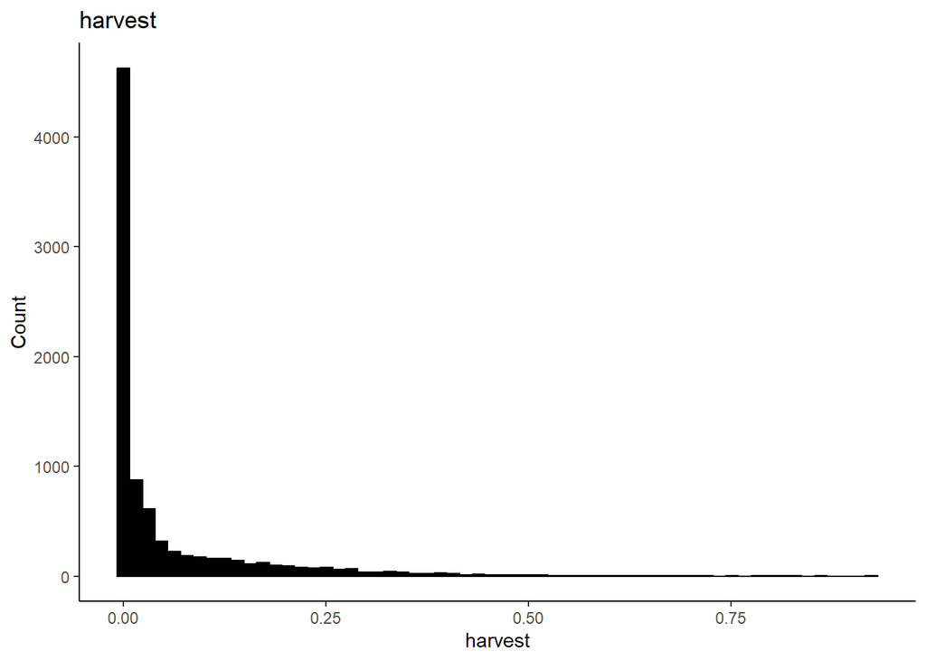

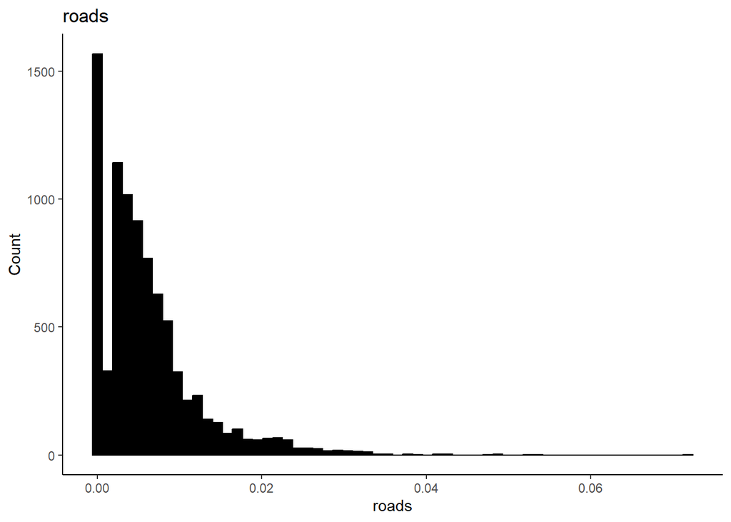

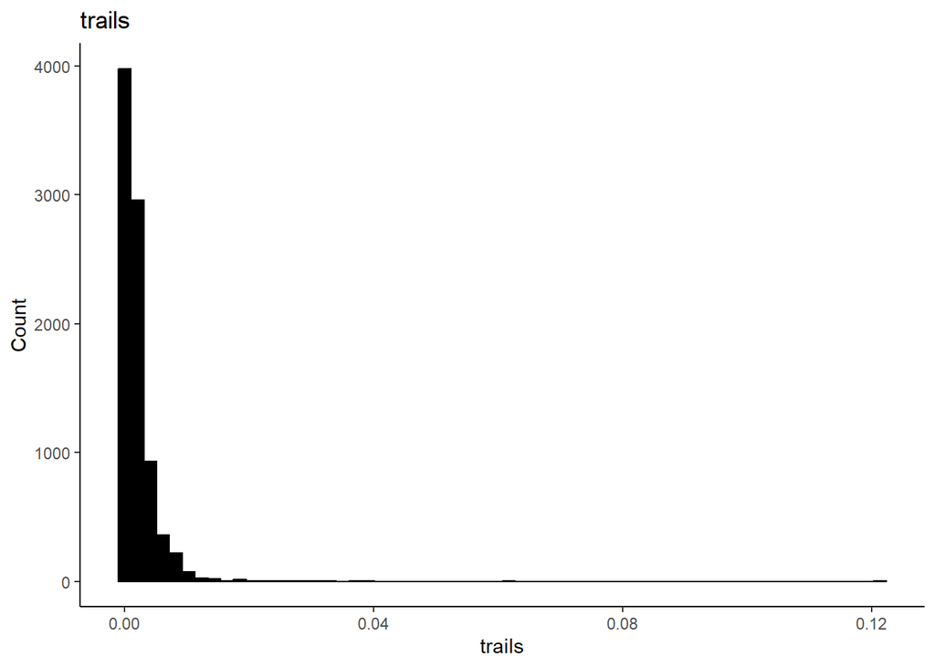

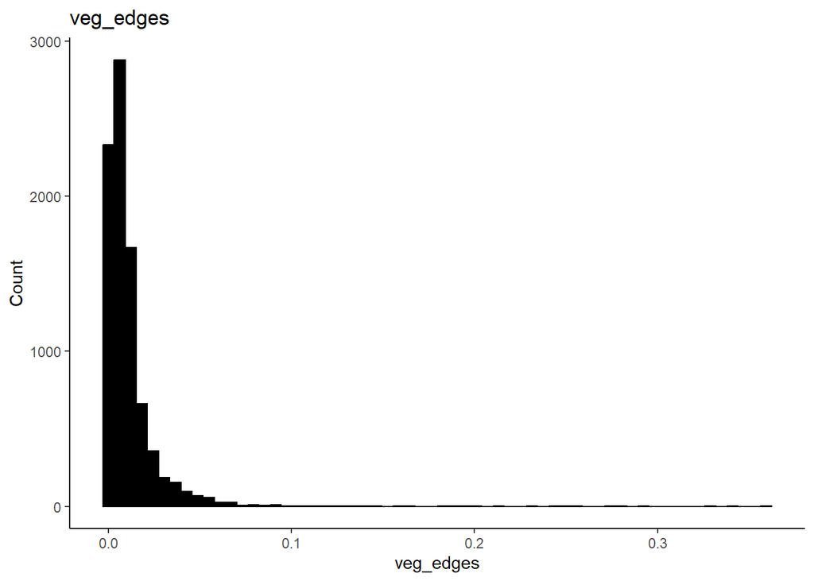

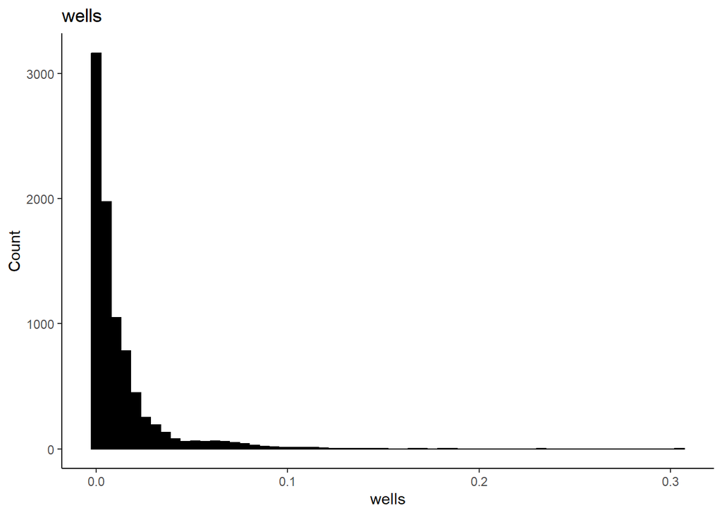

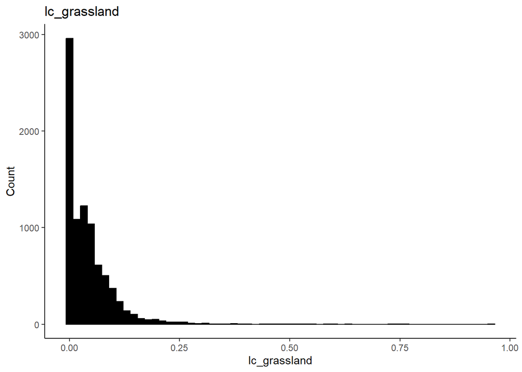

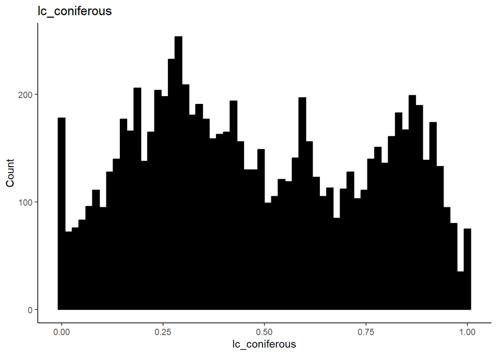

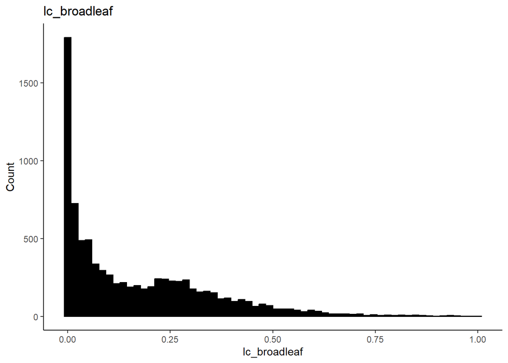

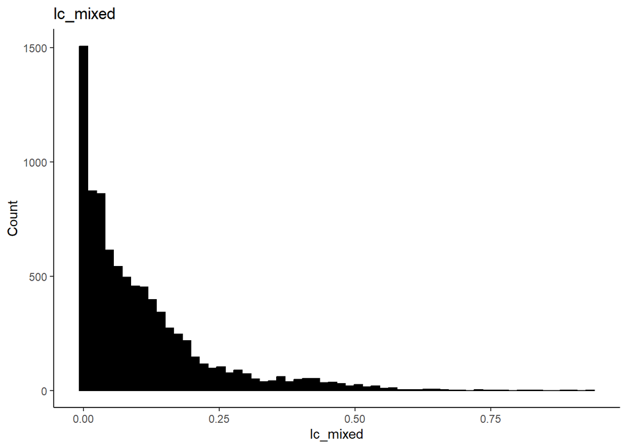

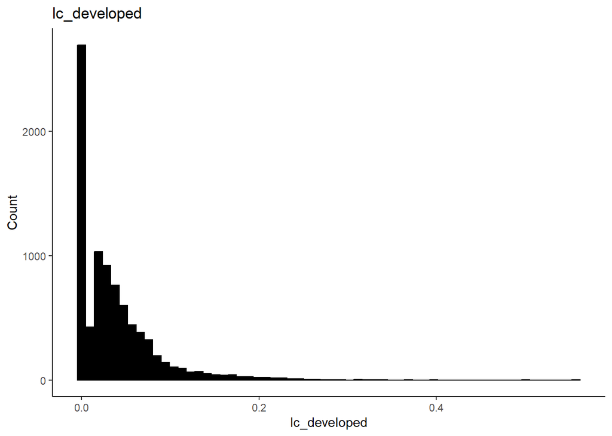

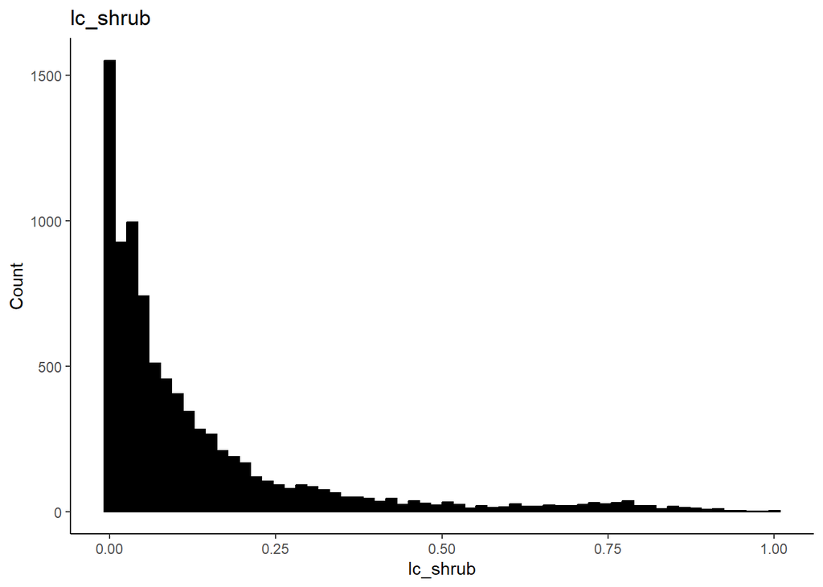

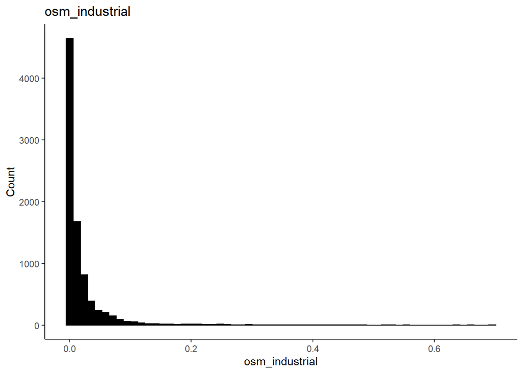

[32 more figures not shown]

```r
data %>%

  select(6:ncol(.)) %>%

  # use imap which will retain both the data (x) and the variable names (y)
  imap(~ ggplot(mapping = aes(x = .x)) +
         geom_histogram(bins = 60, fill = "black", color = "black") +
         labs(title = .y, x = .y, y = "Count") +
         theme_classic())
```

```r
data <- data %>%

  select(-contains("_split"))
```

Now let’s look at correlation among variables. We have a fuck ton of variables to look at so for now we’ll export to excel.

```r
# Histograms for each buffer size
corr_data <- purrr::map(seq(250, 5000, by = 250),
                        ~ data %>%

                          filter(buffer_dist == .x) %>%

                          select(6:ncol(.)) %>%

                          # pairwise complete observations right now since I'm not sure how to manage all the NAs in the configuration metrics yet
                          corrr::correlate(., use = "pairwise.complete.obs",
                                           method = "pearson",
                                           diagonal = NA,
                                           quiet = TRUE) %>%

                          as_tibble() %>%

                          mutate(across(everything(), ~ if_else(row_number() >= min(which(is.na(.))), NA, .))) %>%

                          select(rev(names(.))) %>%

                          relocate(term)

                        ) %>%

  set_names(paste0(seq(250, 5000, by = 250), "m"))
```

[output not shown]

[output cut: 25 more lines]

[output not shown]

```r
writexl::write_xlsx(corr_data, "./data/processed/OSM_all_covariates_correlation.xlsx")
```

# 4. Summary table of covariates

```r
covariate_table <- data %>%

  select(6:ncol(.)) %>%

  mutate(across(everything(), ~ replace_na(.x, 0))) %>%

  summarise(
    across(everything(), list(
      zmean = ~mean(.),
      zmin = ~min(.),
      zmax = ~max(.),
      zmedian = ~median(.),
      zq20 = ~quantile(., probs = 0.20),
      zq80 = ~quantile(., probs = 0.80)
    ))
  ) %>%

  pivot_longer(cols = everything(), names_to = c("Covariate", ".value"), names_sep = "_z") %>%

  mutate(`Median (20%, 80%)` = paste0(round(median, 2),
                                      " (", round(q20, 2),
                                      "–",
                                      round(q80, 2), ")"),

         `Mean (min, max)` = paste0(round(mean, 2),
                                    " (", round(min, 2),
                                    "–",
                                    round(max, 2), ")"),
         ) %>%

  filter(Covariate != 'trails') %>%

  select(-mean, -min, -max, -median, -q20, -q80) %>%

  mutate(Description = "")

writexl::write_xlsx(covariate_table, "./tables/OSM_all_covariates_summary.xlsx")
```

# 5. Export the dataset!

Let’s export the clean, inspected, and reduced data set for analysis in the next script.

```r
write_csv(data, "./data/processed/OSM_proportional_monthly_presence_with_covariates_2021_2022_2023.csv")
```